# Course Project 1

LIANG LI

3/12/2022

# Assignment

## Loading and preprocessing the data

```r
data <- read.csv("activity.csv")
#data = data[!is.na(data$steps),]
data$date <- as.Date(data$date, format = "%Y-%m-%d")
head(data,10)
```

```
##    steps       date interval
## 1     NA 2012-10-01        0
## 2     NA 2012-10-01        5
## 3     NA 2012-10-01       10
## 4     NA 2012-10-01       15
## 5     NA 2012-10-01       20
## 6     NA 2012-10-01       25
## 7     NA 2012-10-01       30
## 8     NA 2012-10-01       35
## 9     NA 2012-10-01       40
## 10    NA 2012-10-01       45
```

```r
mydata <- data %>% group_by(date) %>% summarise_at(vars(steps),funs(sum(.,na.rm=TRUE)))
head(mydata,10)
```

```
## # A tibble: 10 x 2
##    date       steps
##    <date>     <int>
##  1 2012-10-01     0
##  2 2012-10-02   126
##  3 2012-10-03 11352
##  4 2012-10-04 12116
##  5 2012-10-05 13294
##  6 2012-10-06 15420
##  7 2012-10-07 11015
##  8 2012-10-08     0
##  9 2012-10-09 12811
## 10 2012-10-10  9900
```

## What is mean total number of steps taken per day?

### Histogram of the total number of steps taken each day

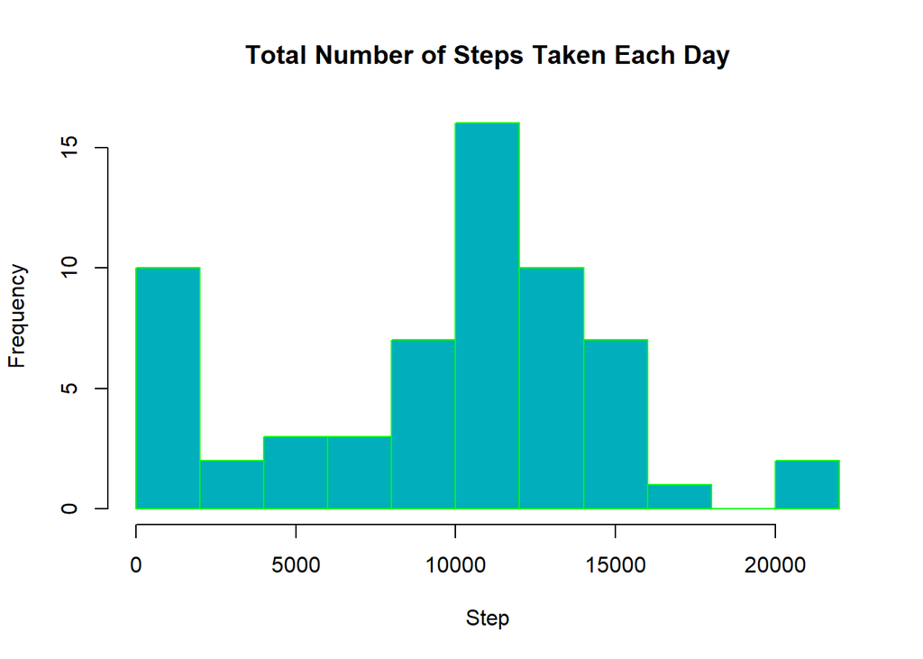

```r
steps <- mydata$steps
hist(steps,
     main = "Total Number of Steps Taken Each Day",
     breaks =15,
     col = "#00AFBB",
     border = "green",
     xlab = "Step")
```

### Mean and median number of steps taken each day

```
## [1] 9354.23
```

```
## [1] 10395
```

## What is the average daily activity pattern?

```r
mydata2 <- data %>% group_by(interval) %>% summarise_at(vars(steps),funs(mean(.,na.rm=TRUE)))
head(mydata2,10)
```

```
## # A tibble: 10 x 2
##    interval  steps
##       <int>  <dbl>
##  1        0 1.72
##  2        5 0.340
##  3       10 0.132
##  4       15 0.151
##  5       20 0.0755
##  6       25 2.09
##  7       30 0.528
##  8       35 0.868
##  9       40 0
## 10       45 1.47
```

### Make a time series plot (i.e. type = “l”) of the 5-minute interval (x-axis) and the average number of steps taken, averaged across all days (y-axis)

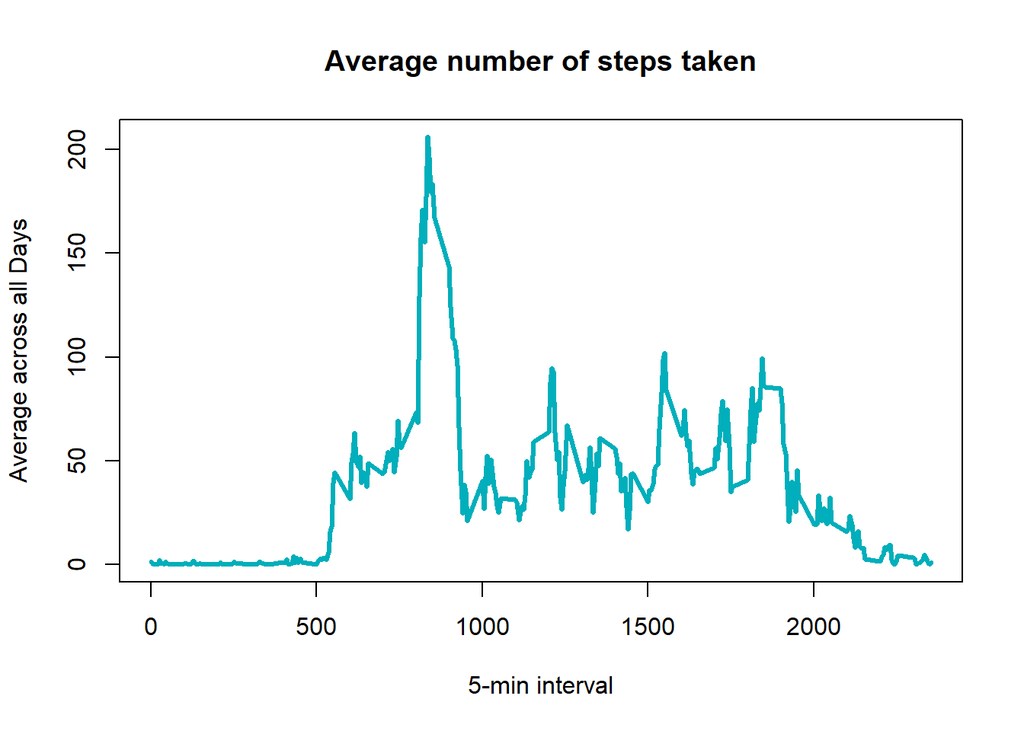

```r
#ggplot(mydata2,main = "Total Number of Steps Taken Each Day",aes(x=date, y=steps))+geom_line(color = "#00AFBB", size = 2)+ggtitle("Time series plot of the average number of steps taken")
plot(mydata2$interval, mydata2$steps, type = "l",
    xlab = "5-min interval",
    ylab = "Average across all Days",
    main = "Average number of steps taken",
    col  = "#00AFBB",
    lwd = 3
    )
```

### Which 5-minute interval, on average across all the days in the dataset, contains the maximum number of steps

```r
colMax <- function(data) sapply(data, max, na.rm = TRUE)
maxval <- colMax(mydata2)
maxval[1]
```

[output not shown]

## Imputing missing values

### Calculate and report the total number of missing values in the dataset

```r
data_NA <- is.na(data)
sum(data_NA)
```

```
## [1] 2304
```

### Devise a strategy for filling in all of the missing values in the dataset.

### The strategy does not need to be sophisticated.

```r
#data$x1[is.na(data$steps)] <- mean(data$steps, na.rm = TRUE)
#create a dataframe to capture the mean step number by days
mydata3 <- data %>% group_by(date) %>% summarise_at(vars(steps),funs(mean(.,na.rm=TRUE)))
mydata3$steps[is.na(mydata3$steps)] <- mean(mydata3$steps, na.rm = TRUE)
data_imputed <- data
for (x in 1:nrow(data_imputed)) {
    record <- data_imputed[x,]
    if (is.na(record$steps)) {
        data_imputed[x,]$steps <- subset(mydata3,date==record$date)$steps  # impute the value based on the mean value of the date.
    }
}
```

### Make a histogram of the total number of steps taken each day and Calculate and report the mean and median total number of steps taken per day. Do these values differ from the estimates from the first part of the assignment? What is the impact of imputing missing data on the estimates of the total daily number of steps?

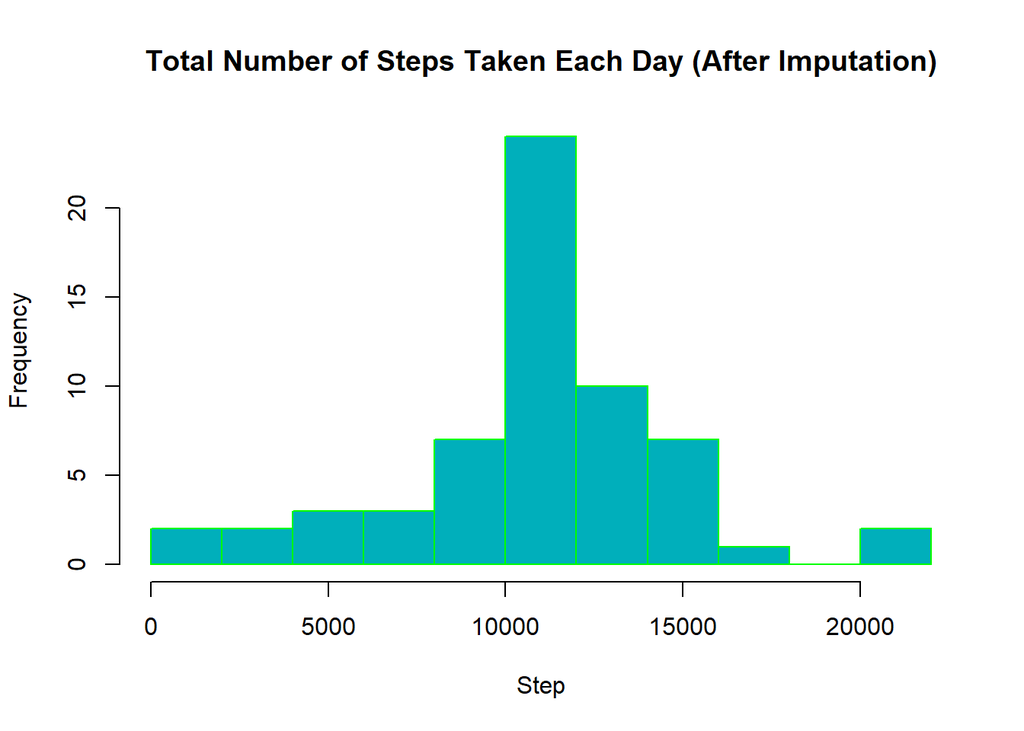

```r
mydata4 <- data_imputed %>% group_by(date) %>% summarise_at(vars(steps),funs(sum(.,na.rm=TRUE)))
steps <- mydata4$steps
hist(steps,
     main = "Total Number of Steps Taken Each Day (After Imputation)",
     breaks =15,
     col = "#00AFBB",
     border = "green",
     xlab = "Step")
```

### Mean and median number of steps taken each day after imputation

```
## [1] 10766.19
```

```
## [1] 10766.19
```

## Are there differences in activity patterns between weekdays and weekends?

### Create a new factor variable in the dataset with two levels – “weekday” and “weekend” indicating whether a given date is a weekday or weekend day.

```
## [1] "weekend"
```

```r
mydata6 <- aggregate(steps ~ interval + isWeekday, data = mydata5, mean)    #process the dataframe so it's grouped by isWeekday and Interval
head(mydata6)
```

```
##   interval isWeekday    steps
## 1        0   weekday 7.006569
## 2        5   weekday 5.384347
## 3       10   weekday 5.139902
## 4       15   weekday 5.162124
## 5       20   weekday 5.073235
## 6       25   weekday 6.295458
```

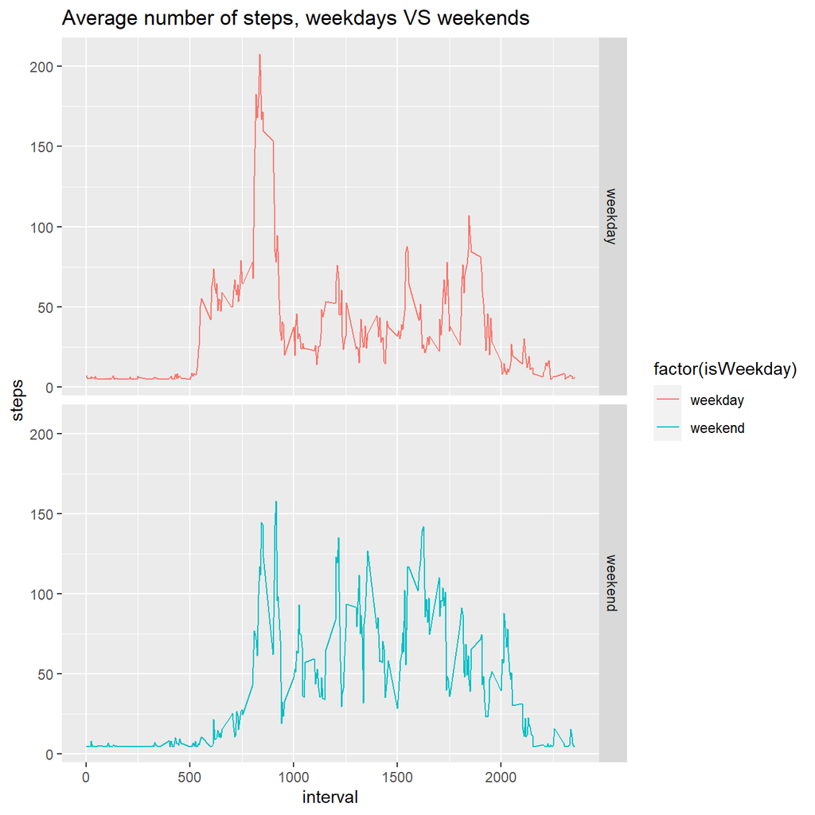

```r
qplot(interval, steps, data = mydata6, geom = "line",
      main = "Average number of steps, weekdays VS weekends",
      colour = factor(isWeekday),
      group = isWeekday) +
      facet_grid(isWeekday ~ ., scale = "fixed")
```